# 01_Alignement_Processing-post-alignment

#### b) Trie des reads alignés par coordonnées génomique

```bash
# usage: samtools sort -@ nb_cpu -o <sorted_bam>  <input_bam>
samtools sort -@ 4 -o SRR1262731_extract.sort.bam SRR1262731_extract.rg.bam
```

#### c) Créaction de l'index

```bash
# usage: samtools index <sorted_bam>
samtools index SRR1262731_extract.sort.bam
```

Qu'est-ce qui s'est passé ?

```bash
ls -l
```

#### d) Visualiser le contenu du BAM

```bash
samtools view -h SRR1262731_extract.sort.bam | head -n6
```

#### e) Contrôle qualité des données alignées

Quelles informations regarder une fois le mapping effectué ?

- Pourcentage total de reads alignés
- Pourcentage de reads pairés “proprement”

Quels outils ?

- Samtools flagstat/stat
- Qualimap [optionnel]
- multiqc [optionnel]

**Samtools :**

```bash
module load samtools/1.13
samtools flagstat | cat # affiche l'aide
samtools stat | cat # affiche l'aide
```

```bash
# usage: samtools flagstat <bam_file>
samtools flagstat SRR1262731_extract.sort.bam
```

Stocker le résultat dans un fichier txt:

```bash
samtools flagstat SRR1262731_extract.sort.bam > SRR1262731_extract.sort.flagstat.txt
```

```bash
samtools stats SRR1262731_extract.sort.bam > SRR1262731_extract.sort.stats.txt
```

**Qualimap :**

```bash
module load qualimap/2.2.2b
qualimap bamqc | cat # affiche l’aide
```

```bash
qualimap bamqc -nt 4 -outdir SRR1262731_extract_qualimap_report --java-mem-size=4G -bam SRR1262731_extract.sort.bam
```

**MultiQC:**

```bash
module load multiqc/1.11
multiqc -h | cat # affiche l'aide
```

```bash
mkdir -p log
multiqc -f . 2>log/multiqc_stdout.txt
```

```bash
# Création d'un archive zip
zip -r SRR1262731_multiqc.zip multiqc_report.html multiqc_data
```

Télécharger le zip pour visualiser le rapport sûr votre machine

#### f) Optimisation de l'espace

Il est recommandé de supprimer tous les fichiers intermediares qui sont volumineux.

Qu'est-ce qu'il est possible de supprimer ?

```bash
ls -lh SRR1262731_extract*
```

```bash
rm SRR1262731_extract.sam
rm SRR1262731_extract.bam
rm SRR1262731_extract.rg.bam
```

## II - Processing post alignement

**Il est nécessaire de préparer les données avant de pouvoir détecter les variants**

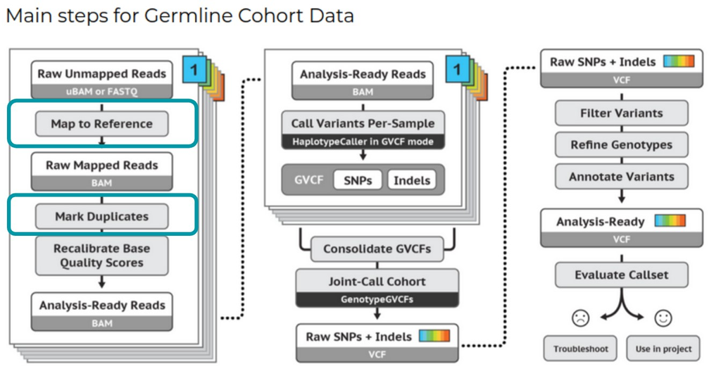

**Les étapes que nous allons voir durant le TP :**

Rappel du workflow :

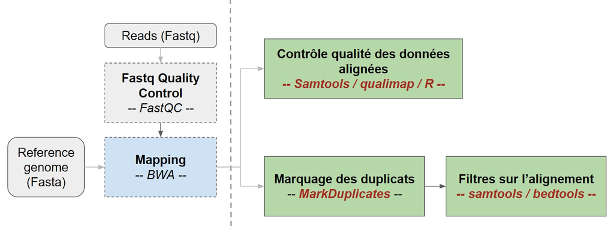